# Inégalités de salaires au Foot

Bro Frédéric - PFC - Liban - 20 janvier 2020

Présentation :

La FIFA (Fédération internationale de football association) fournit une base de données relative aux joueurs classés dans le monde.  
La première ligne correspond au joueur numéro 1 du classement, la deuxième ligne correspond au joueur numéro 2, etc.  
Les résultats sont enregistrés dans le fichier `'Fifa2019.csv'`.

Objectifs :

Comparer les salaires des joueurs de la **Juventus** avec ceux du **FC Barcelona** .

Lequel est-il le plus inégalitaire ?

Table des matières :

1 - Préliminaires avec Pandas

2 - Masse salariale du club de la **Juventus**

3 - Masse salariale du club de la **FC Barcelona**

4 - Défaut d'inégalité de répartition des salaires :

Indice de Gini

> Préliminaires avec Pandas

Retour table des matières

```python
import pylab as pl
import pandas as pa

pl.style.use('bmh')

T = pa.read_csv('Fifa2019.csv')
T.head()
```

|  | nom | age | nationalite | club | valeur | salaire | rupture | attaque/defense | pied |
| --- | --- | --- | --- | --- | --- | --- | --- | --- | --- |
| 0 | L. Messi | 31 | Argentina | FC Barcelona | 110500 | 565 | 226500.0 | Medium/ Medium | Left |
| 1 | Cristiano Ronaldo | 33 | Portugal | Juventus | 77000 | 405 | 127100.0 | High/ Low | Right |
| 2 | Neymar Jr | 26 | Brazil | Paris Saint-Germain | 118500 | 290 | 228100.0 | High/ Medium | Right |
| 3 | De Gea | 27 | Spain | Manchester United | 72000 | 260 | 138600.0 | Medium/ Medium | Right |
| 4 | K. De Bruyne | 27 | Belgium | Manchester City | 102000 | 355 | 196400.0 | High/ High | Right |

> Masse salariale du club de la **Juventus**

Retour table des matières

- Table des joueurs de la Juventus `J` :

```python
J = T.query('club == "Juventus"')
J.head()
```

|  | nom | age | nationalite | club | valeur | salaire | rupture | attaque/defense | pied |
| --- | --- | --- | --- | --- | --- | --- | --- | --- | --- |
| 1 | Cristiano Ronaldo | 33 | Portugal | Juventus | 77000 | 405 | 127100.0 | High/ Low | Right |
| 15 | P. Dybala | 24 | Argentina | Juventus | 89000 | 205 | 153500.0 | High/ Medium | Left |
| 24 | G. Chiellini | 33 | Italy | Juventus | 27000 | 215 | 44600.0 | Medium/ High | Left |
| 64 | Alex Sandro | 27 | Brazil | Juventus | 36500 | 160 | 60200.0 | High/ High | Left |
| 65 | Douglas Costa | 27 | Brazil | Juventus | 46500 | 175 | 76700.0 | High/ Medium | Left |

- Table `JT` obtenue en rangeant la colonne `salaire` de `J` par ordre croissant :

```python
JT = J.sort_values('salaire')
JT.head()
```

|  | nom | age | nationalite | club | valeur | salaire | rupture | attaque/defense | pied |
| --- | --- | --- | --- | --- | --- | --- | --- | --- | --- |
| 13896 | P. Beruatto | 19 | Italy | Juventus | 575 | 5 | 1300.0 | Medium/ High | Left |
| 3418 | M. Kean | 18 | Italy | Juventus | 6500 | 32 | 14800.0 | High/ Medium | Right |
| 3700 | C. Pinsoglio | 28 | Italy | Juventus | 2200 | 44 | 3600.0 | Medium/ Medium | Left |
| 1149 | R. Bentancur | 21 | Uruguay | Juventus | 15500 | 62 | 28700.0 | Medium/ Medium | Right |
| 815 | M. De Sciglio | 25 | Italy | Juventus | 10500 | 78 | 18100.0 | Medium/ Medium | Right |

- Liste des **pourcentages des $k$ premiers joueurs** de `JT` par rapport à l'ensemble du club :

```python
Joueurs_JT = [k/len(JT)*100 for k in range(len(JT)+1)]
Joueurs_JT
```

```
[0.0,
 4.0,
 8.0,
 12.0,
 16.0,
 20.0,
 24.0,
 28.000000000000004,
 32.0,
 36.0,
 40.0,
 44.0,
 48.0,
 52.0,
 56.00000000000001,
 60.0,
 64.0,
 68.0,
 72.0,
 76.0,
 80.0,
 84.0,
 88.0,
 92.0,
 96.0,
 100.0]
```

- Colonne de la **masse salariale cumulée des $k$ premiers joueurs** de `JT` :

```python
JT.salaire.cumsum()
```

```
13896       5
3418       37
3700       81
1149      143
815       221
1049      301
448       392
247       487
245       582
152       677
128       782
243       892
92       1017
103      1162
129      1312
99       1472
73       1632
70       1792
64       1952
139      2112
65       2287
72       2467
15       2672
24       2887
1        3292
Name: salaire, dtype: int64
```

- Liste des pourcentages de la **masse salariale des k premiers joueurs** de `JT` par rapport à la masse salariale du club :

```python
Masse_sal_JT = [0]+list(JT.salaire.cumsum()/JT.salaire.sum()*100)
Masse_sal_JT
```

```
[0,
 0.15188335358444716,
 1.1239368165249088,
 2.4605103280680436,
 4.3438639125151886,
 6.713244228432563,
 9.143377885783718,
 11.907654921020656,
 14.793438639125153,
 17.679222357229648,
 20.565006075334143,
 23.75455650060753,
 27.095990279465372,
 30.893074119076548,
 35.297691373025515,
 39.85419198055893,
 44.714459295261236,
 49.57472660996355,
 54.434993924665854,
 59.295261239368166,
 64.15552855407047,
 69.47144592952613,
 74.93924665856622,
 81.16646415552854,
 87.69744835965977,
 100.0]
```

- Représentation de `Masse_sal_JT` en fonction de `Joueurs_JT` :

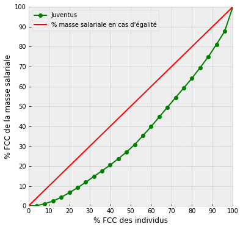

```python
pl.figure(figsize=(6,6))
pl.axis([0,100,0,100])
pl.xticks(range(0,110,10))
pl.yticks(range(0,110,10))

pl.plot(Joueurs_JT,Masse_sal_JT,'o-',
        color='green',label='Juventus')
pl.plot([0,100],[0,100],color='red',
       label="% masse salariale en cas d'égalité")
pl.xlabel('% FCC des individus')
pl.ylabel('% FCC de la masse salariale')
pl.legend()
```

Définition :

> - La courbe verte est appelée Courbe de Lorentz de la masse salariale de la Juventus.
> - Si chaque joueur touchaient le même salaire, alors la courbe de Lorentz serait la droite rouge.

> Masse salariale du club de la **FC Barcelona**

Retour table des matières

- Table des joueurs de lu FC Barcelona `B` :

```python
B = T.query('club == "FC Barcelona"')
```

- Table `BT` obtenue en rangeant la colonne `salaire` de `B` par ordre croissant :

```python
BT = B.sort_values('salaire')
```

- Liste des **pourcentages des $k$ premiers joueurs** de `BT` par rapport à l'ensemble du club :

```python
Joueurs_BT = [k/len(BT)*100 for k in range(len(BT)+1)]
```

- Liste des pourcentages de la **masse salariale des k premiers joueurs** de `BT` par rapport à la masse salariale du club :

```python
Masse_sal_BT = [0]+list(BT.salaire.cumsum()/BT.salaire.sum()*100)
```

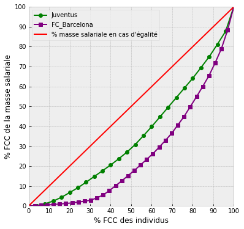

```python
pl.figure(figsize=(6,6))
pl.axis([0,100,0,100])
pl.xticks(range(0,110,10))
pl.yticks(range(0,110,10))

pl.plot(Joueurs_JT,Masse_sal_JT,'o-',
        color='green',label='Juventus')
pl.plot(Joueurs_BT,Masse_sal_BT,'s-',
        color='purple',label='FC_Barcelona')
pl.plot([0,100],[0,100],color='red',
       label="% masse salariale en cas d'égalité")

pl.xlabel('% FCC des individus')
pl.ylabel('% FCC de la masse salariale')
pl.legend()
```

> Défaut d'inégalité de répartition des salaires :

> Indice de Gini

Retour table des matières

Principe :

> L'aire sous la courbe de Lorentz est égale à la somme des aires des trapèzes.
- Fonction `trapèze` de paramètres :
  - `b` *(petite base)*
  - `B` *(grande base)*
  - `h` *(hauteur)*

  Elle renvoie l'aire du trapèze :

```python
def trapèze(b,B,h):
    return (b+B)/2*h
```

- Fonction `aire_sous_courbe` de paramètres :
  - `X` *(liste des abscisses d'une courbe)*
  - `Y` *(liste des ordonnée d'une courbe)*

  Elle renvoie l'aire sous la courbe :

```python
def aire_sous_courbe(X,Y):
    aire = 0
    for k in range(len(X)-1):
        b = Y[k]/100
        B = Y[k+1]/100
        h = X[k+1]/100 - X[k]/100
        aire = aire + trapèze(b,B,h)
    return aire
```

- Coefficient de Gini :

```python
def gini(X,Y):
    return 1 - 2*aire_sous_courbe(X,Y)
```

- Pour la **Juventus** :

```python
gini(Joueurs_JT,Masse_sal_JT)
```

```
0.2950182260024301
```

- Pour le **FC Barcelona** :

```python
gini(Joueurs_BT,Masse_sal_BT)
```

```
0.4788592979620476
```

Fini ...

Retour au début

```python
from IPython.core.display import HTML
htm = open("style_css.txt").read()
HTML(htm)
```